# Non-auto Trip Models

Brian Gregor

June 5, 2016

## Introduction

This document includes code for estimating models for calculating the number of household walking, bicycling, and transit trips. It includes documentation for estimating and testing the models. These estimated models are used in version 3.6 of the RSPM. This version is being developed to improve the modeling of automated vehicles and the interaction between household vehicle travel and the use of other transportation modes. The modeling approach documented here is a major revision of previous work. The key features are:  
* Includes models of bike trips and transit trips as well as walk trips.  
* Uses Hurdle models to account for the inflated numbers of instances of 0 trips.  
* Includes household average DVMT as an independent variable in all of the models so that the calculation of walk, bike, and transit trips will be sensitive to changes in household VMT that result from pricing changes.

## Prepare for Analysis

The ‘pscl’ package is used for estimating the Hurdle model. Code from the library was also modified to write the ‘applyHurdleModel’ function. Following are citations for the ‘pscl’ package and the ‘hurdle’ function in the package:

> Simon Jackman (2015). pscl: Classes and Methods for R Developed in the Political Science Computational Laboratory, Stanford University. Department of Political Science, Stanford University. Stanford, California. R package version 1.4.9. URL http://pscl.stanford.edu/ (Political Science Computational Laboratory, Stanford University)

> Achim Zeileis, Christian Kleiber, Simon Jackman (2008). Regression Models for Count Data in R. Journal of Statistical Software 27(8). URL http://www.jstatsoft.org/v27/i08/.

```r
library(pscl)
```

Metropolitan and non-metropolitan area household datasets are loaded. These datasets are created by ‘household-travel-data’ and ‘household-travel’ modules. The ‘household-travel-data’ module creates a household dataset from the 2001 NHTS files and augmented with roadway supply data from ‘Highway Statistics’ and transit supply data from the ‘National Transit Database’. This dataset includes information about household characteristics, neighborhood characteristics, and household travel characteristics. The ‘household-travel’ module splits the household dataset into metropolitan household and non-metropolitan household datasets. It also adds on estimates of average household DVMT that were calculated using the average DVMT models estimated in this module.

```r
load("data/MetroHh..RData")
load("data/NonMetroHh..RData")
```

Some variables are added to the datasets to test in the estimations. These include log-transforms of household income (Hhincttl), block group population density (Hbppopdn), and average DVMT (Dvmt). They also include the driver-age population (DrvAgePop) and the ratios of vehicles to driver-age population.

```r
#Add variables to metropolitan household dataset
MetroHh..$LogIncome <- log(MetroHh..$Hhincttl)
MetroHh..$Dvmt <- MetroHh..$DvmtAve
MetroHh..$LogDvmt <- log(MetroHh..$Dvmt)
MetroHh..$LogHbppopdn <- log(MetroHh..$Hbppopdn)
MetroHh..$DrvAgePop <- MetroHh..$Hhsize - MetroHh..$Age0to14
MetroHh..$VehPerDrvAgePop <- MetroHh..$Hhvehcnt / MetroHh..$DrvAgePop
#Add variables to non-metropolitan household dataset
NonMetroHh..$LogIncome <- log(NonMetroHh..$Hhincttl)
NonMetroHh..$Dvmt <- NonMetroHh..$DvmtAve
NonMetroHh..$LogDvmt <- log(NonMetroHh..$Dvmt)
NonMetroHh..$LogHbppopdn <- log(NonMetroHh..$Hbppopdn)
NonMetroHh..$DrvAgePop <- NonMetroHh..$Hhsize - NonMetroHh..$Age0to14
NonMetroHh..$VehPerDrvAgePop <- NonMetroHh..$Hhvehcnt / NonMetroHh..$DrvAgePop
```

## Define Hurdle Model Functions

The Hurdle regression models that are used to calculate trips are stored as text strings. This follows the approach used in other modules. The ‘makeHurdleStrings’ function creates text strings for the zero trip and count model components of an estimated Hurdle model object and outputs them in a list. The function takes one argument, a hurdle model object created by the ‘hurdle’ function. It returns a list having two components: ‘Count’ which contains a string representation of the count model component, and ‘Zero’ which contains a string representation of the zero model component.

```r
makeHurdleStrings <- function(HurdleModel_) {
  Coeff. <- coefficients(HurdleModel_)
  #Make formula string for count model
  CountCoeff. <- Coeff.[grep("count", names(Coeff.))]
  names(CountCoeff.) <- gsub("count_", "", names(CountCoeff.))
  names(CountCoeff.)[1] <- "Intercept"
  CountFormula <- paste(paste(CountCoeff., names(CountCoeff.), sep = " * "), collapse = " + ")
  #Make formula string for zero model
  ZeroCoeff. <- Coeff.[grep("zero", names(Coeff.))]
  names(ZeroCoeff.) <- gsub("zero_", "", names(ZeroCoeff.))
  names(ZeroCoeff.)[1] <- "Intercept"
  ZeroFormula <- paste(paste(ZeroCoeff., names(ZeroCoeff.), sep = " * "), collapse = " + ")
  #Return the formulas in a list
  list(Count = CountFormula, Zero = ZeroFormula)
}
```

The ‘applyHurdleModel’ function applies a Hurdle model to a set of data. The function takes two arguments: ‘Data..’ which is a data frame containing all of the independent variables specified in the model for an arbitrary number of households, and ‘Model_’ which is a list containing the Hurdle model specification created by the ‘makeHurdleStrings’ function. The function returns a vector whose elements correspond to the rows in ‘Data..’.

```r
applyHurdleModel <- function(Data.., Model_) {
  #Add the intercept
  Data..$Intercept <- 1
  #Calculate zero term
  Odds. <- exp(eval(parse(text = Model_$Zero), envir = Data..))
  Prob. <- Odds. / (1 + Odds.)
  PZero. <- log(Prob.)
  #Calculate count term
  Mu. <- exp(eval(parse(text = Model_$Count), envir = Data..))
  PCount. <- ppois(0, lambda = Mu., lower.tail = FALSE, log.p = TRUE)
  #Return the number of trips
  exp((PZero. - PCount.) + log(Mu.))
}
```

## Estimate the Metropolitan Models

### Prepare the Estimation Dataset

The metropolitan estimation dataset is culled to exclude variables that are not likely to be significant in the walk, bike, and transit trip models.

```r
ModelVar. <- c("Houseid", "Hhincttl", "Hbppopdn", "Urban","Hbhur", "Hhsize",
               "Hhvehcnt", "Age0to14", "Age15to19", "Age20to29",  "Age30to54",
               "Age55to64", "Age65Plus", "DrvAgePop", "VehPerDrvAgePop",
               "NumWalkTrp", "NumBikeTrp",  "NumTransitTrp", "Fwylnmicap",
               "Tranmilescap", "Dvmt", "LogDvmt", "LogIncome",
               "LogHbppopdn", "Hhc_msa")
MetroHh.. <- MetroHh..[ , ModelVar.]
rm(ModelVar.)
```

Recoded versions of the place type variable (Hbhur) and the MSA variable (Hhc_msa) variable are added to have more meaningful names.

```r
  HbhurNames. <- c(C="Second City", R="Rural", S="Suburban", T="Town", U="Urban Center")
  MetroHh..$PlaceType <- HbhurNames.[MetroHh..$Hbhur]
  MetroNameLookup. <- c("0520"="Atlanta", "0640"="Austin", "1280"="Buffalo", "1122"="Boston", "1520"="Charlotte",
                      "1602"="Chicago", "1642"="Cincinnati", "1692"="Cleveland", "1840"="Columbus",
                      "1922"="Dallas", "2082"="Denver", "2162"="Detroit", "3000"="Grand Rapids",
                      "3120"="Greensboro", "3280"="Hartford", "3320"="Honolulu", "3362"="Houston",
                      "3480"="Indianapolis", "3600"="Jacksonville", "3760"="Kansas City", "4120"="Las Vegas",
                      "4472"="Los Angeles", "4520"="Louisville", "4920"="Memphis", "4992"="Miami",
                      "5082"="Milwaukee", "5120"="Minneapolis", "5360"="Nashville", "5560"="New Orleans",
                      "5602"="New York", "5720"="Norfolk", "5880"="Oklahoma City", "5960"="Orlando",
                      "6162"="Philadelphia", "6200"="Phoenix", "6280"="Pittsburgh", "6442"="Portland",
                      "6480"="Providence", "6640"="Raleigh", "6840"="Rochester", "6922"="Sacramento",
                      "7040"="St. Louis", "7160"="Salt Lake City", "7240"="San Antonio", "7320"="San Diego",
                      "7362"="San Francisco", "7602"="Seattle", "8280"="Tampa", "8872"="Washington",
                      "8960"="West Palm Beach")
  MetroHh..$MsaName <- MetroNameLookup.[MetroHh..$Hhc_msa]
```

There are 19507 records of which 18406 are complete. The incomplete cases are removed in the estimation dataset.

```r
MetroHh.. <- MetroHh..[complete.cases(MetroHh..), ]
```

### Estimate the Models

The process for estimating a trip model for each mode (walk, bike, transit) started with including a large number of independent variables that might affect trip rates and then successively culling them out using Z values and significance determinations for guidance. A Hurdle model is composed of two models: a model of the number of zero values, and a model of the number of non-zero trips. The Hurdle models that were estimated used the default approach of using a binomial logit model to predict zero values and a poisson count model to predict the average number of non-zero trips. The specifications started out the same, but through the culling of non-significant variables, the resulting model specifications for zero and count models of the bike and transit trip models ended up being different. All of the Hurdle models include either Dvmt or LogDvmt as a significant variable. This enables to models to respond to vehicle travel pricing which affects the amount of household travel.

#### Walk Trips Model

In the walk model, vehicle availability (VehPerDrvAgePop) and vehicle travel (LogDvmt) reduce walking. Income (LogIncome), population density and urban mixed use (LogHbppopdn, Urban), and transit service (Tranmilescap) increase walking. The number of persons in the household (Hhsize) also increases the number of walking trips.

```r
MetroWalkModel_ <- hurdle(NumWalkTrp ~ Hhsize + LogIncome + VehPerDrvAgePop +
                          LogHbppopdn + Tranmilescap + Urban + LogDvmt,
                     data = MetroHh.., dist = "poisson", zero.dist = "binomial",
                     link = "logit")
summary(MetroWalkModel_)
```

```
##
## Call:
## hurdle(formula = NumWalkTrp ~ Hhsize + LogIncome + VehPerDrvAgePop +
##     LogHbppopdn + Tranmilescap + Urban + LogDvmt, data = MetroHh..,
##     dist = "poisson", zero.dist = "binomial", link = "logit")
##
## Pearson residuals:
##     Min      1Q  Median      3Q     Max
## -2.4355 -0.5929 -0.4471  0.2235 25.9530
##
## Count model coefficients (truncated poisson with log link):
##                   Estimate Std. Error z value Pr(>|z|)
## (Intercept)      0.0404918  0.0954472   0.424    0.671
## Hhsize           0.2121175  0.0049373  42.963  < 2e-16 ***
## LogIncome        0.0861688  0.0102145   8.436  < 2e-16 ***
## VehPerDrvAgePop -0.3252826  0.0219053 -14.850  < 2e-16 ***
## LogHbppopdn      0.0499452  0.0066795   7.477 7.58e-14 ***
## Tranmilescap     0.0050712  0.0004969  10.206  < 2e-16 ***
## Urban            0.2861660  0.0175976  16.262  < 2e-16 ***
## LogDvmt         -0.1835450  0.0145402 -12.623  < 2e-16 ***
## Zero hurdle model coefficients (binomial with logit link):
##                  Estimate Std. Error z value Pr(>|z|)
## (Intercept)     -3.812064   0.274968 -13.864  < 2e-16 ***
## Hhsize           0.296525   0.016490  17.982  < 2e-16 ***
## LogIncome        0.372712   0.032643  11.418  < 2e-16 ***
## VehPerDrvAgePop -0.561461   0.052807 -10.632  < 2e-16 ***
## LogHbppopdn      0.117342   0.014543   8.068 7.12e-16 ***
## Tranmilescap     0.012893   0.001288  10.007  < 2e-16 ***
## Urban            0.413108   0.047065   8.777  < 2e-16 ***
## LogDvmt         -0.662659   0.050280 -13.179  < 2e-16 ***
## ---
## Signif. codes:  0 '***' 0.001 '**' 0.01 '*' 0.05 '.' 0.1 ' ' 1
##
## Number of iterations in BFGS optimization: 16
## Log-likelihood: -2.69e+04 on 16 Df
```

#### Bike Trips Model

In the bike model, the probability that bike trips are taken is sensitive to the ages of persons in the household. The presence of persons less than 54 years old increases the probability of biking trips (Age0to14, Age15to19, Age20to29, Age30to54). The total number of persons in the household signficantly affects the number of bike trips. Household vehicle travel (Dvmt) reduces the the likelihood and number of bike trips. Transit service (Tranmilescap) also reduces the likelihood and number of bike trips. This suggests that biking and transit are substitutes for one another to some extent.

```r
MetroBikeModel_ <- hurdle(NumBikeTrp ~ Hhsize + Tranmilescap + Dvmt |
                     Age0to14 + Age15to19 + Age20to29 + Age30to54 +
                     Tranmilescap + Dvmt, data = MetroHh.., dist = "poisson",
                     zero.dist = "binomial", link = "logit")
summary(MetroBikeModel_)
```

```
##
## Call:
## hurdle(formula = NumBikeTrp ~ Hhsize + Tranmilescap + Dvmt | Age0to14 +
##     Age15to19 + Age20to29 + Age30to54 + Tranmilescap + Dvmt, data = MetroHh..,
##     dist = "poisson", zero.dist = "binomial", link = "logit")
##
## Pearson residuals:
##     Min      1Q  Median      3Q     Max
## -0.8155 -0.1705 -0.1255 -0.1042 23.9368
##
## Count model coefficients (truncated poisson with log link):
##               Estimate Std. Error z value Pr(>|z|)
## (Intercept)   0.774783   0.114809   6.748 1.49e-11 ***
## Hhsize        0.065011   0.025187   2.581  0.00985 **
## Tranmilescap -0.004229   0.002482  -1.704  0.08836 .
## Dvmt         -0.002578   0.001200  -2.149  0.03167 *
## Zero hurdle model coefficients (binomial with logit link):
##               Estimate Std. Error z value Pr(>|z|)
## (Intercept)  -3.850510   0.141593 -27.194  < 2e-16 ***
## Age0to14      0.396363   0.037094  10.685  < 2e-16 ***
## Age15to19     0.616099   0.069392   8.879  < 2e-16 ***
## Age20to29     0.236421   0.092119   2.566 0.010274 *
## Age30to54     0.414338   0.073846   5.611 2.01e-08 ***
## Tranmilescap -0.011743   0.003307  -3.550 0.000385 ***
## Dvmt         -0.004784   0.001695  -2.823 0.004763 **
## ---
## Signif. codes:  0 '***' 0.001 '**' 0.01 '*' 0.05 '.' 0.1 ' ' 1
##
## Number of iterations in BFGS optimization: 16
## Log-likelihood: -3266 on 11 Df
```

#### Transit Trips Model

```r
MetroTransitModel_ <- hurdle(NumTransitTrp ~ Age0to14 + Age15to19 + Age20to29 +
                        Age30to54 +  Age55to64 + VehPerDrvAgePop + Urban +
                        Dvmt| Age20to29 + Age30to54 +  Age65Plus +
                        VehPerDrvAgePop + LogHbppopdn + Tranmilescap + Urban +
                        LogDvmt, data = MetroHh.., dist = "poisson",
                        zero.dist = "binomial", link = "logit")
summary(MetroTransitModel_)
```

```
##
## Call:
## hurdle(formula = NumTransitTrp ~ Age0to14 + Age15to19 + Age20to29 +
##     Age30to54 + Age55to64 + VehPerDrvAgePop + Urban + Dvmt | Age20to29 +
##     Age30to54 + Age65Plus + VehPerDrvAgePop + LogHbppopdn + Tranmilescap +
##     Urban + LogDvmt, data = MetroHh.., dist = "poisson", zero.dist = "binomial",
##     link = "logit")
##
## Pearson residuals:
##        Min         1Q     Median         3Q        Max
##   -1.58667   -0.21536   -0.13393   -0.08049 2334.29770
##
## Count model coefficients (truncated poisson with log link):
##                  Estimate Std. Error z value Pr(>|z|)
## (Intercept)      0.610891   0.056360  10.839  < 2e-16 ***
## Age0to14         0.117346   0.016155   7.264 3.76e-13 ***
## Age15to19        0.240826   0.029836   8.072 6.94e-16 ***
## Age20to29        0.229904   0.030028   7.656 1.91e-14 ***
## Age30to54        0.192297   0.028993   6.633 3.30e-11 ***
## Age55to64        0.183596   0.039407   4.659 3.18e-06 ***
## VehPerDrvAgePop -0.223284   0.064197  -3.478 0.000505 ***
## Urban            0.124471   0.049628   2.508 0.012139 *
## Dvmt            -0.007012   0.001214  -5.778 7.57e-09 ***
## Zero hurdle model coefficients (binomial with logit link):
##                  Estimate Std. Error z value Pr(>|z|)
## (Intercept)     -4.405839   0.366346 -12.026  < 2e-16 ***
## Age20to29        0.354112   0.060003   5.902 3.60e-09 ***
## Age30to54        0.277401   0.053029   5.231 1.69e-07 ***
## Age65Plus       -0.506725   0.066208  -7.654 1.95e-14 ***
## VehPerDrvAgePop -2.070764   0.116155 -17.828  < 2e-16 ***
## LogHbppopdn      0.283538   0.034701   8.171 3.06e-16 ***
## Tranmilescap     0.040952   0.002372  17.266  < 2e-16 ***
## Urban            0.797300   0.081769   9.751  < 2e-16 ***
## LogDvmt         -0.222847   0.062183  -3.584 0.000339 ***
## ---
## Signif. codes:  0 '***' 0.001 '**' 0.01 '*' 0.05 '.' 0.1 ' ' 1
##
## Number of iterations in BFGS optimization: 24
## Log-likelihood: -6679 on 18 Df
```

## Estimate the Non-Metropolitan Models

### Prepare the Estimation Dataset

The non-metropolitan estimation dataset is culled to exclude variables that are not likely to be significant in the walk, bike, and transit trip models. Several of the variables used in metropolitan models are not available or are only present in very low numbers in the non-metropolitan dataset (Fwylnmicap, Tranmilescap, Urban).

```r
ModelVar. <- c("Houseid", "Hhincttl", "Hbppopdn", "Hbhur", "Hhsize",
               "Hhvehcnt", "Age0to14", "Age15to19", "Age20to29",  "Age30to54",
               "Age55to64", "Age65Plus", "DrvAgePop", "VehPerDrvAgePop",
               "NumWalkTrp", "NumBikeTrp",  "NumTransitTrp", "Dvmt",
               "LogDvmt", "LogIncome", "LogHbppopdn")
NonMetroHh.. <- NonMetroHh..[ , ModelVar.]
rm(ModelVar.)
```

There are 35337 records of which 33194 are complete. The incomplete cases are removed in the estimation dataset.

```r
NonMetroHh.. <- NonMetroHh..[complete.cases(NonMetroHh..), ]
```

### Estimate the Models

The process for estimating Hurdle trip models for the modes was the same as for the metropolitan models, but given that several of the metropolitan variables are not available, the models are simpler. As with the metropolitan models, all of the models include either Dvmt or LogDvmt as a significant variable. This enables to models to respond to vehicle travel pricing which affects the amount of household travel.

#### Walk Trips Model

The non-metropolitan walk model is similar to the metropolitan model except for the exclusion of limited variables (Tranmilescap, Urban). As with the corresponding metropolitan model, vehicle availability (VehPerDrvAgePop) and vehicle travel (LogDvmt) reduce walking. Income (LogIncome), population density (LogHbppopdn), and the number of persons in the household (Hhsize) increases the number of walking trips.

```r
NonMetroWalkModel_ <- hurdle(NumWalkTrp ~ Hhsize + LogIncome + VehPerDrvAgePop +
                             LogHbppopdn + LogDvmt,
                             data = NonMetroHh.., dist = "poisson", zero.dist = "binomial",
                             link = "logit")
summary(NonMetroWalkModel_)
```

```
##
## Call:
## hurdle(formula = NumWalkTrp ~ Hhsize + LogIncome + VehPerDrvAgePop +
##     LogHbppopdn + LogDvmt, data = NonMetroHh.., dist = "poisson",
##     zero.dist = "binomial", link = "logit")
##
## Pearson residuals:
##      Min       1Q   Median       3Q      Max
##  -1.7377  -0.5073  -0.4288  -0.2464 106.4932
##
## Count model coefficients (truncated poisson with log link):
##                  Estimate Std. Error z value Pr(>|z|)
## (Intercept)      1.071374   0.095509  11.218  < 2e-16 ***
## Hhsize           0.187627   0.005280  35.538  < 2e-16 ***
## LogIncome        0.030881   0.012083   2.556   0.0106 *
## VehPerDrvAgePop -0.194870   0.019208 -10.145  < 2e-16 ***
## LogHbppopdn      0.034706   0.004253   8.161 3.32e-16 ***
## LogDvmt         -0.236678   0.018679 -12.671  < 2e-16 ***
## Zero hurdle model coefficients (binomial with logit link):
##                  Estimate Std. Error z value Pr(>|z|)
## (Intercept)     -2.609391   0.195287 -13.362   <2e-16 ***
## Hhsize           0.279076   0.013035  21.410   <2e-16 ***
## LogIncome        0.223072   0.025807   8.644   <2e-16 ***
## VehPerDrvAgePop -0.453531   0.036768 -12.335   <2e-16 ***
## LogHbppopdn      0.087419   0.008059  10.847   <2e-16 ***
## LogDvmt         -0.438302   0.044151  -9.927   <2e-16 ***
## ---
## Signif. codes:  0 '***' 0.001 '**' 0.01 '*' 0.05 '.' 0.1 ' ' 1
##
## Number of iterations in BFGS optimization: 14
## Log-likelihood: -3.548e+04 on 12 Df
```

#### Bike Trips Model

The non-metropolitan bike model is similar to the metropolitan model with the exception that the Tranmilescap is not present. The presence of persons less than 54 years old increases the probability of biking trips (Age0to14, Age15to19, Age20to29, Age30to54), while the amount of household vehicle travel (Dvmt) reduces the probability. The number of bike trips is increased by the total number of persons in the household (Hhsize) and reduced by the amount of household vehicle travel (Dvmt).

```r
NonMetroBikeModel_ <- hurdle(NumBikeTrp ~ Hhsize + Dvmt |
                             Age0to14 + Age15to19 + Age20to29 + Age30to54 +
                             Dvmt, data = NonMetroHh.., dist = "poisson",
                             zero.dist = "binomial", link = "logit")
summary(NonMetroBikeModel_)
```

```
##
## Call:
## hurdle(formula = NumBikeTrp ~ Hhsize + Dvmt | Age0to14 + Age15to19 +
##     Age20to29 + Age30to54 + Dvmt, data = NonMetroHh.., dist = "poisson",
##     zero.dist = "binomial", link = "logit")
##
## Pearson residuals:
##     Min      1Q  Median      3Q     Max
## -1.8458 -0.1842 -0.1329 -0.1064 29.1963
##
## Count model coefficients (truncated poisson with log link):
##               Estimate Std. Error z value Pr(>|z|)
## (Intercept)  0.7141063  0.0617428  11.566  < 2e-16 ***
## Hhsize       0.1008655  0.0152879   6.598 4.18e-11 ***
## Dvmt        -0.0030630  0.0008104  -3.780 0.000157 ***
## Zero hurdle model coefficients (binomial with logit link):
##              Estimate Std. Error z value Pr(>|z|)
## (Intercept) -4.049212   0.077134 -52.496  < 2e-16 ***
## Age0to14     0.381790   0.026440  14.440  < 2e-16 ***
## Age15to19    0.598985   0.049756  12.038  < 2e-16 ***
## Age20to29    0.171681   0.073974   2.321   0.0203 *
## Age30to54    0.503644   0.054101   9.309  < 2e-16 ***
## Dvmt        -0.005635   0.001398  -4.031 5.55e-05 ***
## ---
## Signif. codes:  0 '***' 0.001 '**' 0.01 '*' 0.05 '.' 0.1 ' ' 1
##
## Number of iterations in BFGS optimization: 13
## Log-likelihood: -6732 on 9 Df
```

#### Transit Trips Model

The non-metropolitan transit model differs in several respects from the metropolitan model. As with the other non-metropolitan models, some variables are missing because the are not present or very limited in the data (Tranmilescap, Urban). In addition, there are differences in the person variables used in the model (Hhsize and persons by age group). Also, in the non-metropolitan model household income is significant (LogIncome) but is not significant in the metropolitan model.

```r
NonMetroTransitModel_ <- hurdle(NumTransitTrp ~ Hhsize + VehPerDrvAgePop + LogIncome +
                        Dvmt| LogIncome + Age0to14 + Age20to29 + Age30to54 + Age55to64 +
                        VehPerDrvAgePop + LogHbppopdn +
                        LogDvmt, data = NonMetroHh.., dist = "poisson",
                        zero.dist = "binomial", link = "logit")
summary(NonMetroTransitModel_)
```

```
##
## Call:
## hurdle(formula = NumTransitTrp ~ Hhsize + VehPerDrvAgePop + LogIncome +
##     Dvmt | LogIncome + Age0to14 + Age20to29 + Age30to54 + Age55to64 +
##     VehPerDrvAgePop + LogHbppopdn + LogDvmt, data = NonMetroHh..,
##     dist = "poisson", zero.dist = "binomial", link = "logit")
##
## Pearson residuals:
##        Min         1Q     Median         3Q        Max
## -1.006e+00 -1.106e-01 -7.635e-02 -4.909e-02  8.801e+04
##
## Count model coefficients (truncated poisson with log link):
##                  Estimate Std. Error z value Pr(>|z|)
## (Intercept)      1.976426   0.419318   4.713 2.44e-06 ***
## Hhsize           0.107120   0.030496   3.513 0.000444 ***
## VehPerDrvAgePop -0.324131   0.106913  -3.032 0.002432 **
## LogIncome       -0.138718   0.044948  -3.086 0.002027 **
## Dvmt            -0.001105   0.001754  -0.630 0.528605
## Zero hurdle model coefficients (binomial with logit link):
##                 Estimate Std. Error z value Pr(>|z|)
## (Intercept)     -4.78604    0.61503  -7.782 7.15e-15 ***
## LogIncome        0.16225    0.07621   2.129   0.0333 *
## Age0to14        -0.12543    0.05676  -2.210   0.0271 *
## Age20to29        0.63569    0.08864   7.172 7.40e-13 ***
## Age30to54        0.61335    0.08413   7.290 3.09e-13 ***
## Age55to64        0.41456    0.09972   4.157 3.22e-05 ***
## VehPerDrvAgePop -2.22099    0.16077 -13.815  < 2e-16 ***
## LogHbppopdn      0.33371    0.03602   9.264  < 2e-16 ***
## LogDvmt         -0.65830    0.13355  -4.929 8.26e-07 ***
## ---
## Signif. codes:  0 '***' 0.001 '**' 0.01 '*' 0.05 '.' 0.1 ' ' 1
##
## Number of iterations in BFGS optimization: 21
## Log-likelihood: -3183 on 14 Df
```

## Save the Estimated Models

The models are saved in a nested list that has components for storing metropolitan and non-metropolitan models. Each of these components in turn has components that store the string representations of the models for each mode.

```r
AltModeModels_ <- list()
AltModeModels_$Metro <- list(Walk = makeHurdleStrings(MetroWalkModel_),
                             Bike = makeHurdleStrings(MetroBikeModel_),
                             Transit = makeHurdleStrings(MetroTransitModel_))
AltModeModels_$NonMetro <- list(Walk = makeHurdleStrings(NonMetroWalkModel_),
                                Bike = makeHurdleStrings(NonMetroBikeModel_),
                                Transit = makeHurdleStrings(NonMetroTransitModel_))
save(AltModeModels_, file = "model/AltModeModels_.RData")
```

## Model Comparisons

Several tests are done to compare model predictions with survey observations.

### Predict Estimated Values

The estimated trip rates for metropolitan on non-metropolitan households are calculated using the applyHurdleModel function and the string representations of the models. These are compared with the hurdle prediction function that is part of the pscl function to check that the applyHurdleModel function calculates correctly. As the table below shows, the ratios of the two predictions for all households and all modes is extremely close. It should be noted that there are several reasons for not using the built in prediction method. First, doing so would require that GreenSTEP and RSPM model users have the pscl package installed on their computers. To date, the approach has been to enable the models to be run without installing additional packages. Second, using the built in prediction method uses the model object that contains much more information and is much larger than needed to implement the model (i.e. all of the data used in model estimation, fitted values, residual values, and model statistics). For example, the size of the model object for the metropolitan walk model is over 4MB whereas the size of the string representation of this model is about 1000B.

```r
MetroEstTrips_ <- list(Walk = applyHurdleModel(MetroHh.., AltModeModels_$Metro$Walk),
                       Bike = applyHurdleModel(MetroHh.., AltModeModels_$Metro$Bike),
                       Transit = applyHurdleModel(MetroHh.., AltModeModels_$Metro$Transit))
NonMetroEstTrips_ <- list(Walk = applyHurdleModel(NonMetroHh.., AltModeModels_$NonMetro$Walk),
                       Bike = applyHurdleModel(NonMetroHh.., AltModeModels_$NonMetro$Bike),
                       Transit = applyHurdleModel(NonMetroHh.., AltModeModels_$NonMetro$Transit))
PredDiff.MdTp <- rbind(range(MetroEstTrips_$Walk / predict(MetroWalkModel_) - 1),
                       range(MetroEstTrips_$Bike / predict(MetroBikeModel_) - 1),
                       range(MetroEstTrips_$Transit / predict(MetroTransitModel_) - 1),
                       range(NonMetroEstTrips_$Walk / predict(NonMetroWalkModel_) - 1),
                       range(NonMetroEstTrips_$Bike / predict(NonMetroBikeModel_) - 1),
                       range(NonMetroEstTrips_$Transit / predict(NonMetroTransitModel_) - 1))
colnames(PredDiff.MdTp) <- c("Min", "Max")
rownames(PredDiff.MdTp) <- c("Metro Walk", "Metro Bike", "Metro Transit",
                             "Non-metro Walk", "Non-metro Bike", "Non-metro Transit")
```

```
## Comparison of applyHurdleModel Calculations
## With pscl Hurdle Prediction Function
## Departure of Ratio of Predictions from One
```

```
##                             Min           Max
## Metro Walk         4.440892e-16  7.327472e-15
## Metro Bike         1.332268e-15  6.439294e-15
## Metro Transit     -7.216450e-15  2.131628e-14
## Non-metro Walk    -2.553513e-15  6.217249e-15
## Non-metro Bike    -6.772360e-15  4.440892e-16
## Non-metro Transit -2.498002e-14 -3.663736e-15
```

### Comparison of Observed and Estimated Means

As expected, the estimated mean trip rates are close to the observed means for the entire survey population.

```r
MetroObsVals.. <- MetroHh..[, c("NumWalkTrp", "NumBikeTrp", "NumTransitTrp")]
NonMetroObsVals.. <- NonMetroHh..[, c("NumWalkTrp", "NumBikeTrp", "NumTransitTrp")]
names(MetroObsVals..) <- names(NonMetroObsVals..) <- c("Walk", "Bike", "Transit")
MetroObsMeans. <- unlist(lapply(MetroObsVals.., mean))
NonMetroObsMeans. <- unlist(lapply(NonMetroObsVals.., mean))
MetroEstMeans. <- unlist(lapply(MetroEstTrips_, mean))
NonMetroEstMeans. <- unlist(lapply(NonMetroEstTrips_, mean))
cbind(MetroObsMeans., MetroEstMeans.)
```

```
##         MetroObsMeans. MetroEstMeans.
## Walk         1.5750299     1.56836133
## Bike         0.0730740     0.07314037
## Transit      0.2522547     0.25035005
```

```r
cbind(NonMetroObsMeans., NonMetroEstMeans.)
```

```
##         NonMetroObsMeans. NonMetroEstMeans.
## Walk           0.80147015        0.80065212
## Bike           0.09239622        0.09247139
## Transit        0.03841056        0.03831444
```

Several comparisons of group means are made for metropolitan households. First a function is defined that prepares a table of values of values for the observed means, observed means plus 2 standard errors, observed means minus 2 standard errors, and estimated means by grouping variable.

```r
#Define function to prepare table comparing estimated mean with observed
#mean and 2SE above and below observed mean
compareObsEstGroupMean <- function(GroupVarName, ModeName, Metro = TRUE) {
  if (Metro) {
    ObsVals. <- MetroObsVals..[[ModeName]]
    EstVals. <- MetroEstTrips_[[ModeName]]
    GrpVar. <- MetroHh..[[GroupVarName]]
  } else {
    ObsVals. <- NonMetroObsVals..[[ModeName]]
    EstVals. <- NonMetroEstTrips_[[ModeName]]
    GrpVar. <- NonMetroHh..[[GroupVarName]]
  }
  ObsMean.Gp <- tapply(ObsVals., GrpVar., mean)
  ObsSem.Gp <- tapply(ObsVals., GrpVar., function(x) sd(x) / sqrt(length(x)))
  EstMean.Gp <- tapply(EstVals., GrpVar., mean)
  round(rbind("Obs. Mean - 2SE" = ObsMean.Gp - 2 * ObsSem.Gp,
        "Obs. Mean" = ObsMean.Gp,
        "Obs. Mean + 2SE" = ObsMean.Gp + 2 * ObsSem.Gp,
        "Est. Mean" = EstMean.Gp), 3)
}
```

Dotcharts show that the estimated walk-trip means compare favorably with the observed means by place type (rural, second city, suburban, town, urban center). The results are good for estimated bike trips except for the second city place type. The results are also good for estimated transit trips except for the rural and town place types. The mismatches for the few bike and transit place types are understandable given the small numbers of trips of these modes and small numbers of metropolitan households in these place types. Most importantly, the estimates for both bike trips and transit trips in suburban and urban center place types compare very favorably.

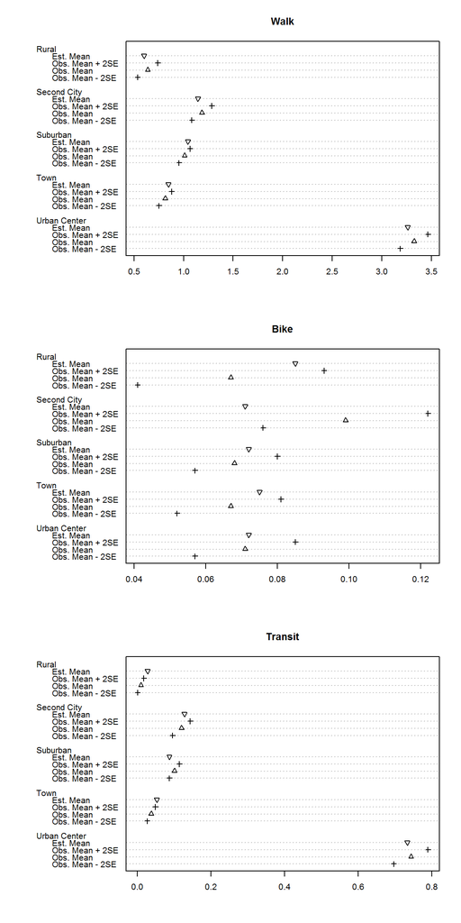

```r
opar <- par(mfrow=c(3,1))
for(Mode in c("Walk", "Bike", "Transit")) {
  dotchart(compareObsEstGroupMean("PlaceType", Mode), pch = c(3,2,3,6),
           main = Mode)
}
```

```r
par(opar)
```

Comparisons are also made by metropolitan area. Estimated trip averages for each mode are compared with the observed averages. Following are calculations.

```r
#Walk averages
MsaWalkComparison.2d <- t(compareObsEstGroupMean("MsaName", "Walk"))
WalkOrder. <- order(abs(MsaWalkComparison.2d[,"Est. Mean"] / MsaWalkComparison.2d[,"Obs. Mean"] - 1))
SortedWalk.2d <- MsaWalkComparison.2d[WalkOrder., c("Obs. Mean - 2SE",
                                                    "Obs. Mean",
                                                    "Est. Mean",
                                                    "Obs. Mean + 2SE")]
MsaWalkOutOfBounds. <- names(
  which(SortedWalk.2d[,"Est. Mean"] < SortedWalk.2d[,"Obs. Mean - 2SE"] |
        SortedWalk.2d[,"Est. Mean"] > SortedWalk.2d[,"Obs. Mean + 2SE"]))
#Bike averages
MsaBikeComparison.2d <- t(compareObsEstGroupMean("MsaName", "Bike"))
BikeOrder. <- order(abs(MsaBikeComparison.2d[,"Est. Mean"] / MsaBikeComparison.2d[,"Obs. Mean"] - 1))
SortedBike.2d <- MsaBikeComparison.2d[BikeOrder., c("Obs. Mean - 2SE",
                                                    "Obs. Mean",
                                                    "Est. Mean",
                                                    "Obs. Mean + 2SE")]
MsaBikeOutOfBounds. <- names(
  which(SortedBike.2d[,"Est. Mean"] < SortedBike.2d[,"Obs. Mean - 2SE"] |
        SortedBike.2d[,"Est. Mean"] > SortedBike.2d[,"Obs. Mean + 2SE"]))
#Transit averages
MsaTransitComparison.2d <- t(compareObsEstGroupMean("MsaName", "Transit"))
TransitOrder. <- order(abs(MsaTransitComparison.2d[,"Est. Mean"] / MsaTransitComparison.2d[,"Obs. Mean"] - 1))
SortedTransit.2d <- MsaTransitComparison.2d[TransitOrder., c("Obs. Mean - 2SE",
                                                    "Obs. Mean",
                                                    "Est. Mean",
                                                    "Obs. Mean + 2SE")]
MsaTransitOutOfBounds. <- names(
  which(SortedTransit.2d[,"Est. Mean"] < SortedTransit.2d[,"Obs. Mean - 2SE"] |
        SortedTransit.2d[,"Est. Mean"] > SortedTransit.2d[,"Obs. Mean + 2SE"]))
```

The average estimated walk trip means are within 2 standard errors of the observed means for all but 7 out of 49 metropolitan areas. The metropolitan areas with estimated means that are out of bounds are Miami, Austin, Dallas, Milwaukee, Las Vegas, San Antonio, Houston. The following table shows how each metropolitan area compares. The table is in order of increasing percentage error of the means.

|  | Obs. Mean - 2SE | Obs. Mean | Est. Mean | Obs. Mean + 2SE |
| --- | --- | --- | --- | --- |
| **Los Angeles** | 1.259 | 1.482 | 1.484 | 1.704 |
| **Jacksonville** | 0.373 | 0.704 | 0.703 | 1.034 |
| **Seattle** | 0.941 | 1.215 | 1.226 | 1.489 |
| **Atlanta** | 0.636 | 0.906 | 0.915 | 1.175 |
| **Portland** | 0.761 | 1.117 | 1.13 | 1.472 |
| **Orlando** | 0.523 | 0.898 | 0.91 | 1.273 |
| **Detroit** | 0.74 | 0.954 | 0.975 | 1.168 |
| **Norfolk** | 0.512 | 0.87 | 0.85 | 1.227 |
| **Washington** | 1.635 | 1.754 | 1.712 | 1.873 |
| **New York** | 2.675 | 2.813 | 2.735 | 2.952 |
| **Oklahoma City** | -0.015 | 0.655 | 0.633 | 1.324 |
| **Buffalo** | 0.738 | 1.014 | 0.976 | 1.289 |
| **New Orleans** | 0.715 | 1.26 | 1.31 | 1.805 |
| **Phoenix** | 0.829 | 1.137 | 1.081 | 1.446 |
| **Chicago** | 1.257 | 1.499 | 1.579 | 1.742 |
| **Raleigh** | 0.384 | 0.611 | 0.577 | 0.839 |
| **San Francisco** | 1.339 | 1.639 | 1.734 | 1.939 |
| **Philadelphia** | 1.117 | 1.434 | 1.334 | 1.752 |
| **Denver** | 0.821 | 1.12 | 1.032 | 1.419 |
| **Minneapolis** | 0.696 | 0.955 | 0.879 | 1.213 |
| **Boston** | 1.149 | 1.411 | 1.272 | 1.673 |
| **Charlotte** | 0.341 | 0.753 | 0.851 | 1.164 |
| **Rochester** | 0.768 | 0.931 | 0.808 | 1.093 |
| **St. Louis** | 0.653 | 0.93 | 0.807 | 1.208 |
| **Cleveland** | 0.783 | 1.125 | 0.973 | 1.467 |
| **Hartford** | 0.462 | 0.82 | 0.691 | 1.178 |
| **San Diego** | 1.191 | 1.681 | 1.404 | 2.17 |
| **Cincinnati** | 0.505 | 0.855 | 0.71 | 1.205 |
| **Tampa** | 0.48 | 0.696 | 0.823 | 0.911 |
| **Sacramento** | 0.95 | 1.379 | 1.123 | 1.809 |
| **Indianapolis** | 0.454 | 0.77 | 0.617 | 1.085 |
| **Kansas City** | 0.305 | 0.548 | 0.669 | 0.791 |
| **Salt Lake City** | 1.141 | 1.907 | 1.483 | 2.673 |
| **Grand Rapids** | 0.46 | 1 | 0.77 | 1.54 |
| **Pittsburgh** | 1.034 | 1.577 | 1.19 | 2.12 |
| **Columbus** | 0.621 | 0.963 | 0.725 | 1.305 |
| **West Palm Beach** | 0.575 | 1.169 | 0.859 | 1.763 |
| **Louisville** | 0.241 | 0.614 | 0.785 | 0.988 |
| **Memphis** | 0.332 | 0.636 | 0.823 | 0.941 |
| **Miami** | 0.737 | 1.038 | 1.373 | 1.339 |
| **Nashville** | 0.42 | 0.782 | 0.525 | 1.143 |
| **Austin** | 0.471 | 0.678 | 0.947 | 0.885 |
| **Dallas** | 0.424 | 0.61 | 0.858 | 0.796 |
| **Providence** | 0.291 | 0.688 | 0.971 | 1.085 |
| **Greensboro** | 0.286 | 0.743 | 0.425 | 1.2 |
| **Milwaukee** | 0.663 | 0.788 | 1.135 | 0.912 |
| **Las Vegas** | 0.563 | 0.893 | 1.327 | 1.223 |
| **San Antonio** | 0.283 | 0.687 | 1.132 | 1.09 |
| **Houston** | 0.362 | 0.499 | 0.911 | 0.635 |

The average estimated bike trip means are within 2 standard errors of the observed means for all but 8 out of 49 metropolitan areas. The metropolitan areas with estimated means that are out of bounds are Washington, San Francisco, Milwaukee, Cleveland, Dallas, Cincinnati, Memphis, Greensboro. The following table shows how each metropolitan area compares. The table is in order of increasing percentage error of the means.

|  | Obs. Mean - 2SE | Obs. Mean | Est. Mean | Obs. Mean + 2SE |
| --- | --- | --- | --- | --- |
| **Indianapolis** | -0.023 | 0.079 | 0.079 | 0.182 |
| **Seattle** | 0.016 | 0.065 | 0.065 | 0.114 |
| **Boston** | 0.035 | 0.08 | 0.079 | 0.125 |
| **Los Angeles** | 0.054 | 0.096 | 0.094 | 0.138 |
| **Detroit** | 0.03 | 0.095 | 0.097 | 0.159 |
| **Kansas City** | -0.003 | 0.075 | 0.077 | 0.153 |
| **Orlando** | -0.021 | 0.071 | 0.069 | 0.164 |
| **New York** | 0.044 | 0.056 | 0.058 | 0.069 |
| **Louisville** | -0.041 | 0.086 | 0.081 | 0.213 |
| **Providence** | -0.015 | 0.091 | 0.085 | 0.197 |
| **Buffalo** | 0.039 | 0.104 | 0.091 | 0.169 |
| **St. Louis** | 0.015 | 0.1 | 0.087 | 0.184 |
| **Denver** | 0.009 | 0.058 | 0.067 | 0.107 |
| **Rochester** | 0.042 | 0.081 | 0.094 | 0.119 |
| **Philadelphia** | 0.03 | 0.096 | 0.079 | 0.161 |
| **New Orleans** | 0.002 | 0.11 | 0.09 | 0.217 |
| **Minneapolis** | 0.036 | 0.1 | 0.08 | 0.164 |
| **Charlotte** | 0 | 0.103 | 0.08 | 0.207 |
| **Phoenix** | 0.025 | 0.116 | 0.09 | 0.207 |
| **Atlanta** | 0.014 | 0.098 | 0.076 | 0.183 |
| **Salt Lake City** | -0.012 | 0.128 | 0.096 | 0.267 |
| **Hartford** | -0.018 | 0.045 | 0.058 | 0.108 |
| **Houston** | 0.055 | 0.11 | 0.078 | 0.166 |
| **Grand Rapids** | -0.023 | 0.077 | 0.1 | 0.177 |
| **San Antonio** | 0.01 | 0.06 | 0.078 | 0.11 |
| **San Diego** | 0.014 | 0.072 | 0.095 | 0.13 |
| **Chicago** | 0.05 | 0.115 | 0.073 | 0.181 |
| **Oklahoma City** | -0.029 | 0.164 | 0.104 | 0.356 |
| **Tampa** | 0.041 | 0.114 | 0.072 | 0.187 |
| **Las Vegas** | -0.002 | 0.045 | 0.062 | 0.091 |
| **Washington** | 0.034 | 0.047 | 0.066 | 0.06 |
| **Sacramento** | 0.074 | 0.186 | 0.093 | 0.299 |
| **San Francisco** | 0.063 | 0.12 | 0.06 | 0.178 |
| **Norfolk** | 0.06 | 0.174 | 0.086 | 0.288 |
| **Jacksonville** | 0.052 | 0.173 | 0.079 | 0.293 |
| **Miami** | 0.007 | 0.186 | 0.081 | 0.365 |
| **Milwaukee** | 0.023 | 0.05 | 0.081 | 0.077 |
| **Portland** | 0.068 | 0.2 | 0.073 | 0.332 |
| **West Palm Beach** | 0.027 | 0.246 | 0.065 | 0.466 |
| **Columbus** | -0.02 | 0.046 | 0.081 | 0.113 |
| **Pittsburgh** | -0.015 | 0.04 | 0.072 | 0.094 |
| **Austin** | 0.003 | 0.035 | 0.067 | 0.068 |
| **Cleveland** | 0.006 | 0.04 | 0.08 | 0.074 |
| **Nashville** | -0.034 | 0.034 | 0.073 | 0.103 |
| **Raleigh** | -0.015 | 0.037 | 0.087 | 0.089 |
| **Dallas** | 0.007 | 0.03 | 0.088 | 0.054 |
| **Cincinnati** | -0.011 | 0.022 | 0.069 | 0.054 |
| **Memphis** | -0.03 | 0.03 | 0.096 | 0.091 |
| **Greensboro** | -0.019 | 0.019 | 0.073 | 0.057 |

The average estimated transit trip means are within 2 standard errors of the observed means for all but 7 out of 49 metropolitan areas. The metropolitan areas with estimated means that are out of bounds are Milwaukee, Austin, Las Vegas, Dallas, Jacksonville, Nashville, Oklahoma City. The following table shows how each metropolitan area compares. The table is in order of increasing percentage error of the means.

|  | Obs. Mean - 2SE | Obs. Mean | Est. Mean | Obs. Mean + 2SE |
| --- | --- | --- | --- | --- |
| **Raleigh** | -0.019 | 0.019 | 0.019 | 0.056 |
| **New York** | 0.56 | 0.605 | 0.608 | 0.649 |
| **Salt Lake City** | 0.014 | 0.128 | 0.129 | 0.242 |
| **Denver** | 0.033 | 0.084 | 0.082 | 0.136 |
| **Portland** | 0.029 | 0.122 | 0.125 | 0.215 |
| **Buffalo** | 0.013 | 0.077 | 0.079 | 0.14 |
| **Kansas City** | -0.007 | 0.034 | 0.033 | 0.075 |
| **Hartford** | -0.056 | 0.056 | 0.054 | 0.169 |
| **Atlanta** | 0.013 | 0.074 | 0.071 | 0.135 |
| **Chicago** | 0.158 | 0.223 | 0.212 | 0.289 |
| **Los Angeles** | 0.101 | 0.16 | 0.152 | 0.218 |
| **Seattle** | 0.087 | 0.153 | 0.145 | 0.219 |
| **Boston** | 0.098 | 0.16 | 0.147 | 0.223 |
| **Tampa** | -0.001 | 0.049 | 0.045 | 0.098 |
| **Washington** | 0.287 | 0.325 | 0.292 | 0.364 |
| **Miami** | 0.059 | 0.154 | 0.138 | 0.249 |
| **Rochester** | 0.023 | 0.062 | 0.054 | 0.101 |
| **Minneapolis** | 0.025 | 0.078 | 0.064 | 0.13 |
| **Pittsburgh** | 0.068 | 0.169 | 0.136 | 0.27 |
| **San Francisco** | 0.141 | 0.212 | 0.257 | 0.282 |
| **Orlando** | -0.002 | 0.061 | 0.074 | 0.125 |
| **St. Louis** | 0.018 | 0.07 | 0.054 | 0.122 |
| **Providence** | -0.021 | 0.052 | 0.064 | 0.125 |
| **Philadelphia** | 0.109 | 0.186 | 0.142 | 0.262 |
| **Phoenix** | 0 | 0.064 | 0.08 | 0.129 |
| **Sacramento** | 0.015 | 0.117 | 0.086 | 0.22 |
| **Louisville** | -0.071 | 0.071 | 0.052 | 0.214 |
| **Cleveland** | 0.038 | 0.125 | 0.09 | 0.212 |
| **San Antonio** | -0.048 | 0.095 | 0.123 | 0.237 |
| **Cincinnati** | -0.021 | 0.08 | 0.056 | 0.181 |
| **San Diego** | 0.077 | 0.229 | 0.157 | 0.38 |
| **West Palm Beach** | -0.031 | 0.031 | 0.042 | 0.092 |
| **New Orleans** | 0.007 | 0.096 | 0.134 | 0.185 |
| **Indianapolis** | -0.048 | 0.048 | 0.027 | 0.143 |
| **Memphis** | -0.03 | 0.03 | 0.046 | 0.091 |
| **Greensboro** | -0.021 | 0.048 | 0.016 | 0.116 |
| **Grand Rapids** | -0.022 | 0.022 | 0.039 | 0.066 |
| **Houston** | 0.001 | 0.038 | 0.068 | 0.076 |
| **Charlotte** | -0.015 | 0.031 | 0.059 | 0.077 |
| **Detroit** | 0.002 | 0.032 | 0.061 | 0.061 |
| **Milwaukee** | 0.027 | 0.055 | 0.106 | 0.083 |
| **Norfolk** | -0.026 | 0.026 | 0.054 | 0.078 |
| **Austin** | -0.008 | 0.035 | 0.082 | 0.078 |
| **Columbus** | -0.019 | 0.019 | 0.048 | 0.056 |
| **Las Vegas** | -0.026 | 0.054 | 0.142 | 0.133 |
| **Dallas** | -0.003 | 0.016 | 0.055 | 0.036 |
| **Jacksonville** | 0 | 0 | 0.041 | 0 |
| **Nashville** | 0 | 0 | 0.021 | 0 |
| **Oklahoma City** | 0 | 0 | 0.031 | 0 |

## Model Sensitivity Tests

The inclusion of household average DVMT in the alternate mode trip models is a very important aspect of these models because it enables the models to respond to changes in household travel that result from changes in vehicle pricing. The RSPM and GreenSTEP models include a travel budget sub-model. The household budget sub-model adjusts household DVMT based on the cost of vehicle travel. Previous alternative mode trip model (walk mode only) did not respond to changes in vehicle travel that occurs as a result of changes in vehicle costs. By including household average DVMT in the alternate mode trip models, the estimates of alternate mode trips will be sensitive to changes in vehicle costs. Following are tests of the sensitivity of alternate mode trips to changes in household DVMT. The average DVMT of every household is decreased by 10% and the walk, bike, and transit trip models are applied. The results are compared with the original trip estimates.

```r
#Calculate metropolitan trips with a 10% reduction on household DVMT
MetroHhScen1.. <- MetroHh..
MetroHhScen1..[,"Dvmt"] <- MetroHh..[,"Dvmt"] * 0.9
MetroHhScen1..[,"LogDvmt"] <- log(MetroHhScen1..[,"Dvmt"])
MetroScen1_ <- list(Walk = applyHurdleModel(MetroHhScen1.., AltModeModels_$Metro$Walk),
                       Bike = applyHurdleModel(MetroHhScen1.., AltModeModels_$Metro$Bike),
                       Transit = applyHurdleModel(MetroHhScen1.., AltModeModels_$Metro$Transit))
MetroScen1_$All <- MetroScen1_$Walk + MetroScen1_$Bike + MetroScen1_$Transit
#Calculate non-metropolitan trips with a 10% reduction in household DVMT
NonMetroHhScen1.. <- NonMetroHh..
NonMetroHhScen1..[,"Dvmt"] <- NonMetroHh..[,"Dvmt"] * 0.9
NonMetroHhScen1..[,"LogDvmt"] <- log(NonMetroHhScen1..[,"Dvmt"])
NonMetroScen1_ <- list(Walk = applyHurdleModel(NonMetroHhScen1.., AltModeModels_$NonMetro$Walk),
                       Bike = applyHurdleModel(NonMetroHhScen1.., AltModeModels_$NonMetro$Bike),
                       Transit = applyHurdleModel(NonMetroHhScen1.., AltModeModels_$NonMetro$Transit))
NonMetroScen1_$All <- NonMetroScen1_$Walk + NonMetroScen1_$Bike + NonMetroScen1_$Transit
#Calculate all trips values for base estimates
MetroEstTrips_$All <- MetroEstTrips_$Walk + MetroEstTrips_$Bike + MetroEstTrips_$Transit
NonMetroEstTrips_$All <- NonMetroEstTrips_$Walk + NonMetroEstTrips_$Bike + NonMetroEstTrips_$Transit
#Calculate the percentage change in alternative mode trips
Scen1PctChg.2d <- cbind(
  Metro = sapply(MetroScen1_, mean) / sapply(MetroEstTrips_, mean),
  NonMetro = sapply(NonMetroScen1_, mean) / sapply(NonMetroEstTrips_, mean))
Scen1PctChg.2d <- round(100 * (Scen1PctChg.2d - 1), 1)
```

The following table compares the percentage changes in metropolitan and non-metropolitan trips by mode that occur with an across-the-board 10% reduction in household average DVMT. As can be seen in the table below, alternative mode models are relatively sensitive to changes in household vehicle travel. A 10% reduction in household DVMT results an approximately 5% increase in trips by alternative modes. This seems reasonable given that households economize on vehicle travel in ways other than switching to other travel modes such as making fewer trips and making shorter trips.

```r
Scen1PctChg.2d
```

```
##         Metro NonMetro
## Walk      5.1      5.4
## Bike      4.1      5.2
## Transit   2.7      6.6
## All       4.7      5.4
```

Although it might seem surprising that transit trip making by non-metropolitan households is more sensitive to changes in vehicle travel than the transit trip making of metropolitan households, it needs to be recognized that the non-metropolitan household trip making starts from a much smaller base. Metropolitan households make an average of 0.25 transit trips daily, whereas non-metropolitan households make an average of 0.038 transit trips. The across-the-board 10% reduction in average household DVMT increases the metropolitan transit average by 0.0068 trip, whereas the non-metropolitan average is increased by 0.0025 trip. For the same reason, reducing average household DVMT increases alternate mode tripmaking in lower density areas more than in higher density areas as the following table shows.

```r
MetroChgByDensity.. <- data.frame(
  "Base_Ave." = tapply(MetroEstTrips_$All, MetroHh..$Hbppopdn, mean),
  "Alt_Ave." = tapply(MetroScen1_$All, MetroHh..$Hbppopdn, mean)
)
MetroChgByDensity..[["Chg_Amt."]] <- MetroChgByDensity..[["Alt_Ave."]] - MetroChgByDensity..[["Base_Ave."]]
MetroChgByDensity..[["Chg_Pct."]] <- 100 * MetroChgByDensity..[["Chg_Amt."]] / MetroChgByDensity..[["Base_Ave."]]
MetroChgByDensity..[["Density"]] <- as.numeric(rownames(MetroChgByDensity..))
rownames(MetroChgByDensity..) <- NULL
MetroChgByDensity..[,c(5,1,2,3,4)]
```

```
##   Density Base_Ave.  Alt_Ave.   Chg_Amt. Chg_Pct.
## 1      50 0.5873929 0.6265937 0.03920079 6.673693
## 2     300 0.8526876 0.9075625 0.05487491 6.435523
## 3     750 0.9496277 1.0097761 0.06014842 6.333896
## 4    1500 1.0312288 1.0951463 0.06391758 6.198196
## 5    3000 1.1933490 1.2644744 0.07112542 5.960152
## 6    7000 1.5997662 1.6872648 0.08749864 5.469465
## 7   17000 3.3461844 3.4880001 0.14181568 4.238131
## 8   30000 6.2707353 6.4629849 0.19224955 3.065821
```

## Define and Save a Function to Apply the Model

The following function implements the estimated models represented in string form. It takes for arguments a data frame containing the required data for households. It returns a list of estimated average daily trips by household for each mode.

```r
calcAltModeTrips <- function(Data.., AltMdModel_, Type) {
  #Check if proper Type specified
  if (!(Type %in% c("Metro", "NonMetro"))) {
    stop("Type must be either 'Metro' or 'NonMetro'")
  }
  #Select the model for the type
  AltMdModel_ <- AltMdModel_[[Type]]
  #Add transformed variables used by the model
  Data..$LogDvmt <- log(Data..$Dvmt)
  Data..$LogIncome <- log(Data..$Hhincttl)
  Data..$LogHbppopdn <- log(Data..$Hbppopdn)
  Data..$DrvAgePop <- Data..$Hhsize - Data..$Age0to14
  Data..$VehPerDrvAgePop <- Data..$Hhvehcnt / Data..$DrvAgePop
  #Define function to apply Hurdle model
  applyHurdleModel <- function(Data.., Model_) {
    #Add the intercept
    Data..$Intercept <- 1
    #Calculate zero term
    Odds. <- exp(eval(parse(text = Model_$Zero), envir = Data..))
    Prob. <- Odds. / (1 + Odds.)
    PZero. <- log(Prob.)
    #Calculate count term
    Mu. <- exp(eval(parse(text = Model_$Count), envir = Data..))
    PCount. <- ppois(0, lambda = Mu., lower.tail = FALSE, log.p = TRUE)
    #Return the number of trips
    exp((PZero. - PCount.) + log(Mu.))
  }
  #Apply the model
  Results_ <- list()
  for(Mode in c("Walk", "Bike", "Transit")) {
    Results_[[Mode]] <- applyHurdleModel(Data.., AltMdModel_[[Mode]])
  }
  Results_
}
```

Apply and test the function. The function duplicates earlier calculations.

```r
TestMetroResults_ <- calcAltModeTrips(MetroHh.., AltModeModels_, Type = "Metro")
all.equal(TestMetroResults_$Walk, MetroEstTrips_$Walk)
```

```
## [1] TRUE
```

```r
all.equal(TestMetroResults_$Bike, MetroEstTrips_$Bike)
```

```
## [1] TRUE
```

```r
all.equal(TestMetroResults_$Transit, MetroEstTrips_$Transit)
```

```
## [1] TRUE
```

```r
TestNonMetroResults_ <- calcAltModeTrips(NonMetroHh.., AltModeModels_, Type = "NonMetro")
all.equal(TestNonMetroResults_$Walk, NonMetroEstTrips_$Walk)
```

```
## [1] TRUE
```

```r
all.equal(TestNonMetroResults_$Bike, NonMetroEstTrips_$Bike)
```

```
## [1] TRUE
```

```r
all.equal(TestNonMetroResults_$Transit, NonMetroEstTrips_$Transit)
```

```
## [1] TRUE
```

Save the function.

```r
save(calcAltModeTrips, file = "model/calcAltModeTrips.RData")
```